# Risk Factor Analysis

## Outcome Variable

**Outcome Variable:** wast_rec90d

## Predictor Variables

**Intervention Variable:** nrooms

**Adjustment Set:**

- arm
- sex
- W_mage
- meducyrs
- feducyrs
- hhwealth_quart
- hfoodsec
- W_mhtcm
- W_nchldlt5
- W_parity
- impfloor
- impsan
- safeh20
- delta_W_mage
- delta_meducyrs
- delta_feducyrs
- delta_hhwealth_quart
- delta_hfoodsec
- delta_W_mhtcm
- delta_W_nchldlt5
- delta_W_parity
- delta_impfloor
- delta_impsan
- delta_safeh20

## Stratifying Variables

The analysis was stratified on these variable(s):

- agecat
- studyid
- country

## Data Summary

| agecat | studyid | country | nrooms | wast_rec90d | n_cell | n |
| --- | --- | --- | --- | --- | --- | --- |
| 0-24 months | ki0047075b-MAL-ED | BANGLADESH | 1 | 0 | 32 | 121 |
| 0-24 months | ki0047075b-MAL-ED | BANGLADESH | 1 | 1 | 61 | 121 |
| 0-24 months | ki0047075b-MAL-ED | BANGLADESH | 2 | 0 | 7 | 121 |
| 0-24 months | ki0047075b-MAL-ED | BANGLADESH | 2 | 1 | 9 | 121 |
| 0-24 months | ki0047075b-MAL-ED | BANGLADESH | 3 | 0 | 2 | 121 |
| 0-24 months | ki0047075b-MAL-ED | BANGLADESH | 3 | 1 | 6 | 121 |
| 0-24 months | ki0047075b-MAL-ED | BANGLADESH | 4+ | 0 | 3 | 121 |
| 0-24 months | ki0047075b-MAL-ED | BANGLADESH | 4+ | 1 | 1 | 121 |
| 0-24 months | ki0047075b-MAL-ED | BRAZIL | 1 | 0 | 0 | 23 |
| 0-24 months | ki0047075b-MAL-ED | BRAZIL | 1 | 1 | 0 | 23 |
| 0-24 months | ki0047075b-MAL-ED | BRAZIL | 2 | 0 | 0 | 23 |
| 0-24 months | ki0047075b-MAL-ED | BRAZIL | 2 | 1 | 2 | 23 |
| 0-24 months | ki0047075b-MAL-ED | BRAZIL | 3 | 0 | 1 | 23 |
| 0-24 months | ki0047075b-MAL-ED | BRAZIL | 3 | 1 | 3 | 23 |
| 0-24 months | ki0047075b-MAL-ED | BRAZIL | 4+ | 0 | 5 | 23 |
| 0-24 months | ki0047075b-MAL-ED | BRAZIL | 4+ | 1 | 12 | 23 |
| 0-24 months | ki0047075b-MAL-ED | INDIA | 1 | 0 | 27 | 173 |
| 0-24 months | ki0047075b-MAL-ED | INDIA | 1 | 1 | 38 | 173 |
| 0-24 months | ki0047075b-MAL-ED | INDIA | 2 | 0 | 23 | 173 |
| 0-24 months | ki0047075b-MAL-ED | INDIA | 2 | 1 | 41 | 173 |
| 0-24 months | ki0047075b-MAL-ED | INDIA | 3 | 0 | 14 | 173 |
| 0-24 months | ki0047075b-MAL-ED | INDIA | 3 | 1 | 18 | 173 |
| 0-24 months | ki0047075b-MAL-ED | INDIA | 4+ | 0 | 3 | 173 |
| 0-24 months | ki0047075b-MAL-ED | INDIA | 4+ | 1 | 9 | 173 |
| 0-24 months | ki0047075b-MAL-ED | NEPAL | 1 | 0 | 4 | 92 |
| 0-24 months | ki0047075b-MAL-ED | NEPAL | 1 | 1 | 23 | 92 |
| 0-24 months | ki0047075b-MAL-ED | NEPAL | 2 | 0 | 1 | 92 |
| 0-24 months | ki0047075b-MAL-ED | NEPAL | 2 | 1 | 5 | 92 |
| 0-24 months | ki0047075b-MAL-ED | NEPAL | 3 | 0 | 0 | 92 |
| 0-24 months | ki0047075b-MAL-ED | NEPAL | 3 | 1 | 6 | 92 |

[output cut: 354 more lines]

The following strata were considered:

- agecat: 0-24 months, studyid: ki0047075b-MAL-ED, country: BANGLADESH
- agecat: 0-24 months, studyid: ki0047075b-MAL-ED, country: BRAZIL
- agecat: 0-24 months, studyid: ki0047075b-MAL-ED, country: INDIA
- agecat: 0-24 months, studyid: ki0047075b-MAL-ED, country: NEPAL
- agecat: 0-24 months, studyid: ki0047075b-MAL-ED, country: PERU
- agecat: 0-24 months, studyid: ki0047075b-MAL-ED, country: SOUTH AFRICA
- agecat: 0-24 months, studyid: ki0047075b-MAL-ED, country: TANZANIA, UNITED REPUBLIC OF
- agecat: 0-24 months, studyid: ki1000108-CMC-V-BCS-2002, country: INDIA
- agecat: 0-24 months, studyid: ki1000108-IRC, country: INDIA
- agecat: 0-24 months, studyid: ki1017093b-PROVIDE, country: BANGLADESH
- agecat: 0-24 months, studyid: ki1017093c-NIH-Crypto, country: BANGLADESH
- agecat: 0-24 months, studyid: ki1113344-GMS-Nepal, country: NEPAL
- agecat: 0-24 months, studyid: ki1114097-CONTENT, country: PERU
- agecat: 0-24 months, studyid: ki1135781-COHORTS, country: INDIA
- agecat: 0-24 months, studyid: kiGH5241-JiVitA-3, country: BANGLADESH
- agecat: 0-24 months, studyid: kiGH5241-JiVitA-4, country: BANGLADESH
- agecat: 0-6 months, studyid: ki0047075b-MAL-ED, country: BANGLADESH
- agecat: 0-6 months, studyid: ki0047075b-MAL-ED, country: BRAZIL
- agecat: 0-6 months, studyid: ki0047075b-MAL-ED, country: INDIA
- agecat: 0-6 months, studyid: ki0047075b-MAL-ED, country: NEPAL
- agecat: 0-6 months, studyid: ki0047075b-MAL-ED, country: PERU
- agecat: 0-6 months, studyid: ki0047075b-MAL-ED, country: SOUTH AFRICA
- agecat: 0-6 months, studyid: ki0047075b-MAL-ED, country: TANZANIA, UNITED REPUBLIC OF
- agecat: 0-6 months, studyid: ki1000108-CMC-V-BCS-2002, country: INDIA
- agecat: 0-6 months, studyid: ki1000108-IRC, country: INDIA
- agecat: 0-6 months, studyid: ki1017093b-PROVIDE, country: BANGLADESH
- agecat: 0-6 months, studyid: ki1017093c-NIH-Crypto, country: BANGLADESH
- agecat: 0-6 months, studyid: ki1113344-GMS-Nepal, country: NEPAL
- agecat: 0-6 months, studyid: ki1114097-CONTENT, country: PERU
- agecat: 0-6 months, studyid: ki1135781-COHORTS, country: INDIA
- agecat: 0-6 months, studyid: kiGH5241-JiVitA-3, country: BANGLADESH
- agecat: 0-6 months, studyid: kiGH5241-JiVitA-4, country: BANGLADESH
- agecat: 6-24 months, studyid: ki0047075b-MAL-ED, country: BANGLADESH
- agecat: 6-24 months, studyid: ki0047075b-MAL-ED, country: BRAZIL
- agecat: 6-24 months, studyid: ki0047075b-MAL-ED, country: INDIA
- agecat: 6-24 months, studyid: ki0047075b-MAL-ED, country: NEPAL
- agecat: 6-24 months, studyid: ki0047075b-MAL-ED, country: PERU
- agecat: 6-24 months, studyid: ki0047075b-MAL-ED, country: SOUTH AFRICA
- agecat: 6-24 months, studyid: ki0047075b-MAL-ED, country: TANZANIA, UNITED REPUBLIC OF
- agecat: 6-24 months, studyid: ki1000108-CMC-V-BCS-2002, country: INDIA
- agecat: 6-24 months, studyid: ki1000108-IRC, country: INDIA
- agecat: 6-24 months, studyid: ki1017093b-PROVIDE, country: BANGLADESH
- agecat: 6-24 months, studyid: ki1017093c-NIH-Crypto, country: BANGLADESH
- agecat: 6-24 months, studyid: ki1113344-GMS-Nepal, country: NEPAL
- agecat: 6-24 months, studyid: ki1114097-CONTENT, country: PERU
- agecat: 6-24 months, studyid: ki1135781-COHORTS, country: INDIA
- agecat: 6-24 months, studyid: kiGH5241-JiVitA-3, country: BANGLADESH
- agecat: 6-24 months, studyid: kiGH5241-JiVitA-4, country: BANGLADESH

### Dropped Strata

Some strata were dropped due to rare outcomes:

- agecat: 0-24 months, studyid: ki0047075b-MAL-ED, country: BANGLADESH
- agecat: 0-24 months, studyid: ki0047075b-MAL-ED, country: BRAZIL
- agecat: 0-24 months, studyid: ki0047075b-MAL-ED, country: INDIA
- agecat: 0-24 months, studyid: ki0047075b-MAL-ED, country: NEPAL
- agecat: 0-24 months, studyid: ki0047075b-MAL-ED, country: PERU
- agecat: 0-24 months, studyid: ki0047075b-MAL-ED, country: SOUTH AFRICA
- agecat: 0-24 months, studyid: ki0047075b-MAL-ED, country: TANZANIA, UNITED REPUBLIC OF
- agecat: 0-24 months, studyid: ki1000108-CMC-V-BCS-2002, country: INDIA
- agecat: 0-24 months, studyid: ki1017093b-PROVIDE, country: BANGLADESH
- agecat: 0-24 months, studyid: ki1114097-CONTENT, country: PERU
- agecat: 0-24 months, studyid: ki1135781-COHORTS, country: INDIA
- agecat: 0-6 months, studyid: ki0047075b-MAL-ED, country: BANGLADESH
- agecat: 0-6 months, studyid: ki0047075b-MAL-ED, country: BRAZIL
- agecat: 0-6 months, studyid: ki0047075b-MAL-ED, country: INDIA
- agecat: 0-6 months, studyid: ki0047075b-MAL-ED, country: NEPAL
- agecat: 0-6 months, studyid: ki0047075b-MAL-ED, country: PERU
- agecat: 0-6 months, studyid: ki0047075b-MAL-ED, country: SOUTH AFRICA
- agecat: 0-6 months, studyid: ki0047075b-MAL-ED, country: TANZANIA, UNITED REPUBLIC OF
- agecat: 0-6 months, studyid: ki1000108-CMC-V-BCS-2002, country: INDIA
- agecat: 0-6 months, studyid: ki1000108-IRC, country: INDIA
- agecat: 0-6 months, studyid: ki1017093b-PROVIDE, country: BANGLADESH
- agecat: 0-6 months, studyid: ki1017093c-NIH-Crypto, country: BANGLADESH
- agecat: 0-6 months, studyid: ki1114097-CONTENT, country: PERU
- agecat: 0-6 months, studyid: ki1135781-COHORTS, country: INDIA
- agecat: 6-24 months, studyid: ki0047075b-MAL-ED, country: BANGLADESH
- agecat: 6-24 months, studyid: ki0047075b-MAL-ED, country: BRAZIL
- agecat: 6-24 months, studyid: ki0047075b-MAL-ED, country: INDIA
- agecat: 6-24 months, studyid: ki0047075b-MAL-ED, country: NEPAL
- agecat: 6-24 months, studyid: ki0047075b-MAL-ED, country: PERU
- agecat: 6-24 months, studyid: ki0047075b-MAL-ED, country: SOUTH AFRICA
- agecat: 6-24 months, studyid: ki0047075b-MAL-ED, country: TANZANIA, UNITED REPUBLIC OF
- agecat: 6-24 months, studyid: ki1000108-CMC-V-BCS-2002, country: INDIA
- agecat: 6-24 months, studyid: ki1000108-IRC, country: INDIA
- agecat: 6-24 months, studyid: ki1017093b-PROVIDE, country: BANGLADESH
- agecat: 6-24 months, studyid: ki1017093c-NIH-Crypto, country: BANGLADESH
- agecat: 6-24 months, studyid: ki1114097-CONTENT, country: PERU
- agecat: 6-24 months, studyid: ki1135781-COHORTS, country: INDIA
- agecat: 6-24 months, studyid: kiGH5241-JiVitA-3, country: BANGLADESH

## Methods Detail

We’re interested in the causal parameters $E[Y_a]$ for all values of $a \in \mathcal{A}$. These parameters represent the mean outcome if, possibly contrary to fact, we intervened to set all units to have $A=a$. Under the randomization and positivity assumptions, these are identified by the statistical parameters $\psi_a=E_W[E_{Y|A,W}(Y|A=a,W)]$. In addition, we’re interested in the mean of $Y$, $E[Y]$ under no intervention (the observed mean). We will estimate these parameters by using SuperLearner to fit the relevant likelihood factors – $E_{Y|A,W}(Y|A=a,W)$ and $p(A=a|W)$, and then updating our likelihood fit using a joint TMLE.

For unadjusted analyses ($W=\{\}$), initial likelihoods were estimated using Lrnr_glm to estimate the simple $E(Y|A)$ and Lrnr_mean to estimate $p(A)$. For adjusted analyses, a small library containing Lrnr_glmnet, Lrnr_xgboost, and Lrnr_mean was used.

Having estimated these parameters, we will then use the delta method to estimate relative risks and attributable risks relative to a prespecified baseline level of $A$.

# Results Detail

## Results Plots

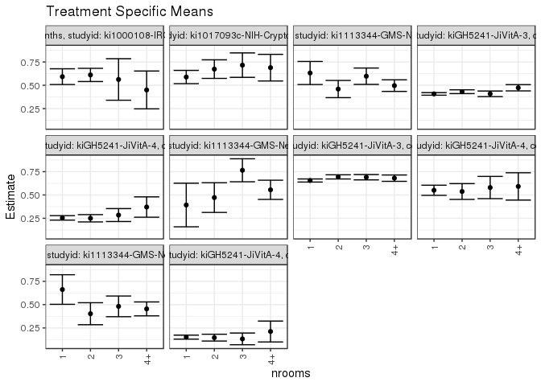

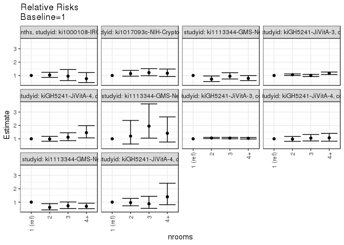

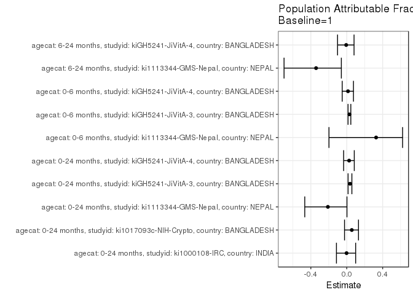

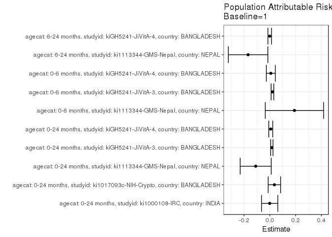

## Results Table

### Parameter: TSM

| agecat | studyid | country | intervention_level | baseline_level | estimate | ci_lower | ci_upper |
| --- | --- | --- | --- | --- | --- | --- | --- |
| 0-24 months | ki1000108-IRC | INDIA | 1 | NA | 0.5925926 | 0.5081592 | 0.6770260 |
| 0-24 months | ki1000108-IRC | INDIA | 2 | NA | 0.6111111 | 0.5401543 | 0.6820679 |
| 0-24 months | ki1000108-IRC | INDIA | 3 | NA | 0.5625000 | 0.3398407 | 0.7851593 |
| 0-24 months | ki1000108-IRC | INDIA | 4+ | NA | 0.4500000 | 0.2471890 | 0.6528110 |
| 0-24 months | ki1017093c-NIH-Crypto | BANGLADESH | 1 | NA | 0.5886794 | 0.5175627 | 0.6597961 |
| 0-24 months | ki1017093c-NIH-Crypto | BANGLADESH | 2 | NA | 0.6733681 | 0.5736997 | 0.7730365 |
| 0-24 months | ki1017093c-NIH-Crypto | BANGLADESH | 3 | NA | 0.7161341 | 0.5850867 | 0.8471816 |
| 0-24 months | ki1017093c-NIH-Crypto | BANGLADESH | 4+ | NA | 0.6890208 | 0.5463989 | 0.8316426 |
| 0-24 months | ki1113344-GMS-Nepal | NEPAL | 1 | NA | 0.6319540 | 0.5083756 | 0.7555324 |
| 0-24 months | ki1113344-GMS-Nepal | NEPAL | 2 | NA | 0.4597392 | 0.3676600 | 0.5518183 |
| 0-24 months | ki1113344-GMS-Nepal | NEPAL | 3 | NA | 0.5974025 | 0.5097482 | 0.6850569 |
| 0-24 months | ki1113344-GMS-Nepal | NEPAL | 4+ | NA | 0.4965681 | 0.4344036 | 0.5587326 |
| 0-24 months | kiGH5241-JiVitA-3 | BANGLADESH | 1 | NA | 0.4075142 | 0.3937892 | 0.4212392 |
| 0-24 months | kiGH5241-JiVitA-3 | BANGLADESH | 2 | NA | 0.4311236 | 0.4109326 | 0.4513145 |
| 0-24 months | kiGH5241-JiVitA-3 | BANGLADESH | 3 | NA | 0.4084684 | 0.3783693 | 0.4385674 |
| 0-24 months | kiGH5241-JiVitA-3 | BANGLADESH | 4+ | NA | 0.4735775 | 0.4399674 | 0.5071876 |
| 0-24 months | kiGH5241-JiVitA-4 | BANGLADESH | 1 | NA | 0.2543990 | 0.2306150 | 0.2781830 |
| 0-24 months | kiGH5241-JiVitA-4 | BANGLADESH | 2 | NA | 0.2502564 | 0.2112254 | 0.2892875 |
| 0-24 months | kiGH5241-JiVitA-4 | BANGLADESH | 3 | NA | 0.2845711 | 0.2152574 | 0.3538849 |
| 0-24 months | kiGH5241-JiVitA-4 | BANGLADESH | 4+ | NA | 0.3707833 | 0.2617614 | 0.4798053 |
| 0-6 months | ki1113344-GMS-Nepal | NEPAL | 1 | NA | 0.3925415 | 0.1586586 | 0.6264244 |
| 0-6 months | ki1113344-GMS-Nepal | NEPAL | 2 | NA | 0.4720285 | 0.3129273 | 0.6311298 |
| 0-6 months | ki1113344-GMS-Nepal | NEPAL | 3 | NA | 0.7648584 | 0.6415515 | 0.8881652 |
| 0-6 months | ki1113344-GMS-Nepal | NEPAL | 4+ | NA | 0.5552401 | 0.4522743 | 0.6582059 |
| 0-6 months | kiGH5241-JiVitA-3 | BANGLADESH | 1 | NA | 0.6552406 | 0.6387672 | 0.6717139 |
| 0-6 months | kiGH5241-JiVitA-3 | BANGLADESH | 2 | NA | 0.6939887 | 0.6716344 | 0.7163431 |
| 0-6 months | kiGH5241-JiVitA-3 | BANGLADESH | 3 | NA | 0.6903733 | 0.6619419 | 0.7188048 |
| 0-6 months | kiGH5241-JiVitA-3 | BANGLADESH | 4+ | NA | 0.6803559 | 0.6463378 | 0.7143740 |
| 0-6 months | kiGH5241-JiVitA-4 | BANGLADESH | 1 | NA | 0.5504983 | 0.4960893 | 0.6049073 |
| 0-6 months | kiGH5241-JiVitA-4 | BANGLADESH | 2 | NA | 0.5372039 | 0.4526380 | 0.6217697 |
| 0-6 months | kiGH5241-JiVitA-4 | BANGLADESH | 3 | NA | 0.5796816 | 0.4604925 | 0.6988707 |
| 0-6 months | kiGH5241-JiVitA-4 | BANGLADESH | 4+ | NA | 0.5916711 | 0.4452497 | 0.7380926 |
| 6-24 months | ki1113344-GMS-Nepal | NEPAL | 1 | NA | 0.6621087 | 0.5033333 | 0.8208841 |
| 6-24 months | ki1113344-GMS-Nepal | NEPAL | 2 | NA | 0.4027379 | 0.2848413 | 0.5206346 |
| 6-24 months | ki1113344-GMS-Nepal | NEPAL | 3 | NA | 0.4816291 | 0.3706422 | 0.5926160 |
| 6-24 months | ki1113344-GMS-Nepal | NEPAL | 4+ | NA | 0.4545749 | 0.3800522 | 0.5290975 |
| 6-24 months | kiGH5241-JiVitA-4 | BANGLADESH | 1 | NA | 0.1518611 | 0.1304645 | 0.1732577 |
| 6-24 months | kiGH5241-JiVitA-4 | BANGLADESH | 2 | NA | 0.1462655 | 0.1098122 | 0.1827188 |
| 6-24 months | kiGH5241-JiVitA-4 | BANGLADESH | 3 | NA | 0.1327867 | 0.0699013 | 0.1956721 |
| 6-24 months | kiGH5241-JiVitA-4 | BANGLADESH | 4+ | NA | 0.2120513 | 0.1001667 | 0.3239358 |

### Parameter: E(Y)

| agecat | studyid | country | intervention_level | baseline_level | estimate | ci_lower | ci_upper |
| --- | --- | --- | --- | --- | --- | --- | --- |
| 0-24 months | ki1000108-IRC | INDIA | NA | NA | 0.5913706 | 0.5391835 | 0.6435576 |
| 0-24 months | ki1017093c-NIH-Crypto | BANGLADESH | NA | NA | 0.6237942 | 0.5698223 | 0.6777662 |
| 0-24 months | ki1113344-GMS-Nepal | NEPAL | NA | NA | 0.5222816 | 0.4773852 | 0.5671781 |
| 0-24 months | kiGH5241-JiVitA-3 | BANGLADESH | NA | NA | 0.4228277 | 0.4116994 | 0.4339560 |
| 0-24 months | kiGH5241-JiVitA-4 | BANGLADESH | NA | NA | 0.2613103 | 0.2419607 | 0.2806599 |
| 0-6 months | ki1113344-GMS-Nepal | NEPAL | NA | NA | 0.5833333 | 0.5108676 | 0.6557991 |
| 0-6 months | kiGH5241-JiVitA-3 | BANGLADESH | NA | NA | 0.6754701 | 0.6621313 | 0.6888089 |
| 0-6 months | kiGH5241-JiVitA-4 | BANGLADESH | NA | NA | 0.5583942 | 0.5167799 | 0.6000084 |
| 6-24 months | ki1113344-GMS-Nepal | NEPAL | NA | NA | 0.4934383 | 0.4388573 | 0.5480193 |
| 6-24 months | kiGH5241-JiVitA-4 | BANGLADESH | NA | NA | 0.1508986 | 0.1332882 | 0.1685090 |

### Parameter: RR

| agecat | studyid | country | intervention_level | baseline_level | estimate | ci_lower | ci_upper |
| --- | --- | --- | --- | --- | --- | --- | --- |
| 0-24 months | ki1000108-IRC | INDIA | 1 | 1 | 1.0000000 | 1.0000000 | 1.0000000 |
| 0-24 months | ki1000108-IRC | INDIA | 2 | 1 | 1.0312500 | 0.8580769 | 1.2393722 |
| 0-24 months | ki1000108-IRC | INDIA | 3 | 1 | 0.9492188 | 0.6232698 | 1.4456279 |
| 0-24 months | ki1000108-IRC | INDIA | 4+ | 1 | 0.7593750 | 0.4733474 | 1.2182394 |
| 0-24 months | ki1017093c-NIH-Crypto | BANGLADESH | 1 | 1 | 1.0000000 | 1.0000000 | 1.0000000 |
| 0-24 months | ki1017093c-NIH-Crypto | BANGLADESH | 2 | 1 | 1.1438621 | 0.9468577 | 1.3818555 |
| 0-24 months | ki1017093c-NIH-Crypto | BANGLADESH | 3 | 1 | 1.2165096 | 0.9794387 | 1.5109629 |
| 0-24 months | ki1017093c-NIH-Crypto | BANGLADESH | 4+ | 1 | 1.1704517 | 0.9245608 | 1.4817383 |
| 0-24 months | ki1113344-GMS-Nepal | NEPAL | 1 | 1 | 1.0000000 | 1.0000000 | 1.0000000 |
| 0-24 months | ki1113344-GMS-Nepal | NEPAL | 2 | 1 | 0.7274883 | 0.5497359 | 0.9627154 |
| 0-24 months | ki1113344-GMS-Nepal | NEPAL | 3 | 1 | 0.9453259 | 0.7401755 | 1.2073369 |
| 0-24 months | ki1113344-GMS-Nepal | NEPAL | 4+ | 1 | 0.7857662 | 0.6228802 | 0.9912477 |
| 0-24 months | kiGH5241-JiVitA-3 | BANGLADESH | 1 | 1 | 1.0000000 | 1.0000000 | 1.0000000 |
| 0-24 months | kiGH5241-JiVitA-3 | BANGLADESH | 2 | 1 | 1.0579351 | 0.9992322 | 1.1200866 |
| 0-24 months | kiGH5241-JiVitA-3 | BANGLADESH | 3 | 1 | 1.0023414 | 0.9246910 | 1.0865125 |
| 0-24 months | kiGH5241-JiVitA-3 | BANGLADESH | 4+ | 1 | 1.1621129 | 1.0746235 | 1.2567253 |
| 0-24 months | kiGH5241-JiVitA-4 | BANGLADESH | 1 | 1 | 1.0000000 | 1.0000000 | 1.0000000 |
| 0-24 months | kiGH5241-JiVitA-4 | BANGLADESH | 2 | 1 | 0.9837165 | 0.8201323 | 1.1799293 |
| 0-24 months | kiGH5241-JiVitA-4 | BANGLADESH | 3 | 1 | 1.1186018 | 0.8617465 | 1.4520162 |
| 0-24 months | kiGH5241-JiVitA-4 | BANGLADESH | 4+ | 1 | 1.4574876 | 1.0705696 | 1.9842429 |
| 0-6 months | ki1113344-GMS-Nepal | NEPAL | 1 | 1 | 1.0000000 | 1.0000000 | 1.0000000 |
| 0-6 months | ki1113344-GMS-Nepal | NEPAL | 2 | 1 | 1.2024933 | 0.6092454 | 2.3734117 |
| 0-6 months | ki1113344-GMS-Nepal | NEPAL | 3 | 1 | 1.9484777 | 1.0512411 | 3.6115080 |
| 0-6 months | ki1113344-GMS-Nepal | NEPAL | 4+ | 1 | 1.4144749 | 0.7581980 | 2.6388083 |
| 0-6 months | kiGH5241-JiVitA-3 | BANGLADESH | 1 | 1 | 1.0000000 | 1.0000000 | 1.0000000 |
| 0-6 months | kiGH5241-JiVitA-3 | BANGLADESH | 2 | 1 | 1.0591358 | 1.0171133 | 1.1028946 |
| 0-6 months | kiGH5241-JiVitA-3 | BANGLADESH | 3 | 1 | 1.0536181 | 1.0044488 | 1.1051944 |
| 0-6 months | kiGH5241-JiVitA-3 | BANGLADESH | 4+ | 1 | 1.0383299 | 0.9822201 | 1.0976451 |
| 0-6 months | kiGH5241-JiVitA-4 | BANGLADESH | 1 | 1 | 1.0000000 | 1.0000000 | 1.0000000 |
| 0-6 months | kiGH5241-JiVitA-4 | BANGLADESH | 2 | 1 | 0.9758502 | 0.8103507 | 1.1751500 |
| 0-6 months | kiGH5241-JiVitA-4 | BANGLADESH | 3 | 1 | 1.0530126 | 0.8380541 | 1.3231073 |
| 0-6 months | kiGH5241-JiVitA-4 | BANGLADESH | 4+ | 1 | 1.0747920 | 0.8233393 | 1.4030398 |
| 6-24 months | ki1113344-GMS-Nepal | NEPAL | 1 | 1 | 1.0000000 | 1.0000000 | 1.0000000 |
| 6-24 months | ki1113344-GMS-Nepal | NEPAL | 2 | 1 | 0.6082655 | 0.4166240 | 0.8880596 |
| 6-24 months | ki1113344-GMS-Nepal | NEPAL | 3 | 1 | 0.7274169 | 0.5216256 | 1.0143969 |
| 6-24 months | ki1113344-GMS-Nepal | NEPAL | 4+ | 1 | 0.6865562 | 0.5133630 | 0.9181795 |
| 6-24 months | kiGH5241-JiVitA-4 | BANGLADESH | 1 | 1 | 1.0000000 | 1.0000000 | 1.0000000 |
| 6-24 months | kiGH5241-JiVitA-4 | BANGLADESH | 2 | 1 | 0.9631536 | 0.7233352 | 1.2824826 |
| 6-24 months | kiGH5241-JiVitA-4 | BANGLADESH | 3 | 1 | 0.8743958 | 0.5334940 | 1.4331333 |
| 6-24 months | kiGH5241-JiVitA-4 | BANGLADESH | 4+ | 1 | 1.3963505 | 0.8087670 | 2.4108236 |

### Parameter: PAR

| agecat | studyid | country | intervention_level | baseline_level | estimate | ci_lower | ci_upper |
| --- | --- | --- | --- | --- | --- | --- | --- |
| 0-24 months | ki1000108-IRC | INDIA | 1 | NA | -0.0012220 | -0.0643943 | 0.0619503 |
| 0-24 months | ki1017093c-NIH-Crypto | BANGLADESH | 1 | NA | 0.0351148 | -0.0133780 | 0.0836076 |
| 0-24 months | ki1113344-GMS-Nepal | NEPAL | 1 | NA | -0.1096724 | -0.2302149 | 0.0108702 |
| 0-24 months | kiGH5241-JiVitA-3 | BANGLADESH | 1 | NA | 0.0153135 | 0.0063149 | 0.0243121 |
| 0-24 months | kiGH5241-JiVitA-4 | BANGLADESH | 1 | NA | 0.0069113 | -0.0085952 | 0.0224178 |
| 0-6 months | ki1113344-GMS-Nepal | NEPAL | 1 | NA | 0.1907918 | -0.0356627 | 0.4172463 |
| 0-6 months | kiGH5241-JiVitA-3 | BANGLADESH | 1 | NA | 0.0202296 | 0.0097337 | 0.0307254 |
| 0-6 months | kiGH5241-JiVitA-4 | BANGLADESH | 1 | NA | 0.0078959 | -0.0270700 | 0.0428618 |
| 6-24 months | ki1113344-GMS-Nepal | NEPAL | 1 | NA | -0.1686704 | -0.3221086 | -0.0152323 |
| 6-24 months | kiGH5241-JiVitA-4 | BANGLADESH | 1 | NA | -0.0009624 | -0.0147883 | 0.0128634 |

### Parameter: PAF

| agecat | studyid | country | intervention_level | baseline_level | estimate | ci_lower | ci_upper |
| --- | --- | --- | --- | --- | --- | --- | --- |
| 0-24 months | ki1000108-IRC | INDIA | 1 | NA | -0.0020664 | -0.1147791 | 0.0992501 |
| 0-24 months | ki1017093c-NIH-Crypto | BANGLADESH | 1 | NA | 0.0562923 | -0.0246944 | 0.1308782 |
| 0-24 months | ki1113344-GMS-Nepal | NEPAL | 1 | NA | -0.2099871 | -0.4676777 | 0.0024590 |
| 0-24 months | kiGH5241-JiVitA-3 | BANGLADESH | 1 | NA | 0.0362168 | 0.0147564 | 0.0572098 |
| 0-24 months | kiGH5241-JiVitA-4 | BANGLADESH | 1 | NA | 0.0264486 | -0.0346023 | 0.0838970 |
| 0-6 months | ki1113344-GMS-Nepal | NEPAL | 1 | NA | 0.3270717 | -0.1978959 | 0.6219768 |
| 0-6 months | kiGH5241-JiVitA-3 | BANGLADESH | 1 | NA | 0.0299488 | 0.0143097 | 0.0453399 |
| 0-6 months | kiGH5241-JiVitA-4 | BANGLADESH | 1 | NA | 0.0141404 | -0.0505216 | 0.0748222 |
| 6-24 months | ki1113344-GMS-Nepal | NEPAL | 1 | NA | -0.3418267 | -0.6983591 | -0.0601403 |
| 6-24 months | kiGH5241-JiVitA-4 | BANGLADESH | 1 | NA | -0.0063781 | -0.1023777 | 0.0812615 |